# Análisis de Fraude Ideal Insurance

Grupo 2

2023-08-22

## Introducción

Este documento describe el proceso de exploración y modelado de un conjunto de datos de Ideal Insurance para predecir fraudes cometidos con la póliza de seguro de las personas. También exploraremos relaciones causales utilizando Grafos Acíclicos Dirigidos (DAGs).

## Carga las librerias necesarias

```r
#install.packages(c("readr", "caret", "DAGitty", "gbm"))
library(readr)
library(caret)
#library(DAGitty)
library(tidyverse)
library(gbm)
```

## Carga el conjunto de Datos

```r
data <- read_csv("Dataset_Proyecto_Final_Data_Science.csv")
#data <- as.data.frame(data1)
head(data)
```

```
## # A tibble: 6 × 34
##     tpa policy_ref member_id   sex   dob policy_start_dt policy_end_dt prod_code
##   <dbl>      <dbl>     <dbl> <dbl> <dbl>           <dbl>         <dbl>     <dbl>
## 1     0    9.00e13   9.61e10     0 28594           40045         40409         0
## 2     0    9.64e13   8.64e10     0 12833           39908         40245         0
## 3     0    9.64e13   9.66e10     1 13223           39908         40245         0
## 4     0    9.64e13   9.66e10     1 13223           39908         40245         0
## 5     0    9.64e13   9.66e10     1 13223           39908         40245         0
## 6     0    9.64e13   9.22e10     1 28572           39908         40245         0
## # ℹ 26 more variables: policy_type <dbl>, sum_insured <dbl>, claim_ref <dbl>,
## #   claim_dt <dbl>, hos_zipcode <dbl>, admit_dt <dbl>, discharge_dt <dbl>,
## #   payment_dt <dbl>, claim_amt <dbl>, nursing_chg <dbl>, surgery_chg <dbl>,
## #   cons_fee <dbl>, test_chg <dbl>, pharmacy_cost <dbl>, other_chg <dbl>,
## #   pre_hosp_exp <dbl>, post_hosp_exp <dbl>, other_chg_non_hosp <dbl>,
## #   copayment <dbl>, settle_amt <dbl>, payment_type <dbl>, hosp_type <dbl>,
## #   fraud <dbl>, recommentdation_sub_genuine <dbl>, …
```

## Estructura y Resumen del Conjunto de Datos

```r
str(data)
```

```
## spc_tbl_ [94,494 × 34] (S3: spec_tbl_df/tbl_df/tbl/data.frame)
##  $ tpa                            : num [1:94494] 0 0 0 0 0 0 0 0 0 0 ...
##  $ policy_ref                     : num [1:94494] 9.00e+13 9.64e+13 9.64e+13 9.64e+13 9.64e+13 ...
##  $ member_id                      : num [1:94494] 9.61e+10 8.64e+10 9.66e+10 9.66e+10 9.66e+10 ...
##  $ sex                            : num [1:94494] 0 0 1 1 1 1 1 1 0 0 ...
##  $ dob                            : num [1:94494] 28594 12833 13223 13223 13223 ...
##  $ policy_start_dt                : num [1:94494] 40045 39908 39908 39908 39908 ...
##  $ policy_end_dt                  : num [1:94494] 40409 40245 40245 40245 40245 ...
##  $ prod_code                      : num [1:94494] 0 0 0 0 0 0 0 0 0 0 ...
##  $ policy_type                    : num [1:94494] 3 3 3 3 3 3 3 3 3 3 ...
##  $ sum_insured                    : num [1:94494] 8750 25000 25000 25000 25000 25000 25000 25000 25000 25000 ...
##  $ claim_ref                      : num [1:94494] 7.68e+19 7.68e+19 9.07e+17 7.27e+19 6.88e+17 ...
##  $ claim_dt                       : num [1:94494] 40174 39826 40170 40171 40143 ...
##  $ hos_zipcode                    : num [1:94494] 9.34e+08 7.71e+08 7.71e+08 8.85e+07 8.85e+07 ...
##  $ admit_dt                       : num [1:94494] 40145 39857 40164 40170 40139 ...
##  $ discharge_dt                   : num [1:94494] 40169 39977 40169 40237 40144 ...
##  $ payment_dt                     : num [1:94494] 40195 40178 40196 40196 40144 ...
##  $ claim_amt                      : num [1:94494] 923 3151 6798 3988 1295 ...
##  $ nursing_chg                    : num [1:94494] 0 0 0 0 0 0 0 0 0 0 ...
##  $ surgery_chg                    : num [1:94494] 0 0 0 0 0 0 0 0 0 0 ...
##  $ cons_fee                       : num [1:94494] 0 0 0 0 0 0 0 0 0 0 ...
##  $ test_chg                       : num [1:94494] 0 0 0 0 0 0 0 0 0 0 ...
##  $ pharmacy_cost                  : num [1:94494] 0 0 0 0 0 0 0 0 0 0 ...
##  $ other_chg                      : num [1:94494] 0 0 0 0 0 0 0 0 0 0 ...
##  $ pre_hosp_exp                   : num [1:94494] 0 0 0 0 0 0 0 0 0 0 ...
##  $ post_hosp_exp                  : num [1:94494] 0 0 0 0 0 0 0 0 0 0 ...
##  $ other_chg_non_hosp             : num [1:94494] 0 0 0 0 0 0 0 0 0 0 ...
##  $ copayment                      : num [1:94494] 0 0 0 0 0 0 0 0 0 0 ...
##  $ settle_amt                     : num [1:94494] 570 3150 6525 3680 1165 ...
##  $ payment_type                   : num [1:94494] 1 0 0 0 0 0 0 0 0 0 ...
##  $ hosp_type                      : num [1:94494] 0 1 1 1 1 1 1 1 1 1 ...
##  $ fraud                          : num [1:94494] 1 0 1 0 0 0 0 0 0 0 ...
##  $ recommentdation_sub_genuine    : num [1:94494] 1 1 1 1 1 1 1 1 1 1 ...
##  $ recommentdation_sub_discuss    : num [1:94494] 0 0 0 0 0 0 0 0 0 0 ...
##  $ recommentdation_sub_investigate: num [1:94494] 0 0 0 0 0 0 0 0 0 0 ...
##  - attr(*, "spec")=
##   .. cols(
##   ..   tpa = col_double(),
##   ..   policy_ref = col_double(),
##   ..   member_id = col_double(),
```

[output cut: 18 more lines]

```
##   ..   pharmacy_cost = col_double(),
##   ..   other_chg = col_double(),
##   ..   pre_hosp_exp = col_double(),
##   ..   post_hosp_exp = col_double(),
##   ..   other_chg_non_hosp = col_double(),
##   ..   copayment = col_double(),
##   ..   settle_amt = col_double(),
##   ..   payment_type = col_double(),
##   ..   hosp_type = col_double(),
##   ..   fraud = col_double(),
##   ..   recommentdation_sub_genuine = col_double(),
##   ..   recommentdation_sub_discuss = col_double(),
##   ..   recommentdation_sub_investigate = col_double()
##   .. )
##  - attr(*, "problems")=<externalptr>
```

```r
summary(data)
```

```
##       tpa           policy_ref          member_id              sex
##  Min.   : 0.000   Min.   :7.203e+13   Min.   :7.203e+10   Min.   :0.000
##  1st Qu.: 1.000   1st Qu.:7.940e+13   1st Qu.:7.935e+10   1st Qu.:0.000
##  Median : 3.000   Median :8.616e+13   Median :8.595e+10   Median :0.000
##  Mean   : 4.351   Mean   :8.575e+13   Mean   :8.588e+10   Mean   :0.468
##  3rd Qu.: 5.000   3rd Qu.:9.206e+13   3rd Qu.:9.246e+10   3rd Qu.:1.000
##  Max.   :22.000   Max.   :9.962e+13   Max.   :9.962e+10   Max.   :1.000
##
##       dob         policy_start_dt policy_end_dt     prod_code
##  Min.   :    20   Min.   :37970   Min.   :38350   Min.   :0.0000
##  1st Qu.: 20515   1st Qu.:39491   1st Qu.:39877   1st Qu.:0.0000
##  Median : 26678   Median :39927   Median :40302   Median :0.0000
##  Mean   : 26358   Mean   :39813   Mean   :40196   Mean   :0.3513
##  3rd Qu.: 31008   3rd Qu.:40088   3rd Qu.:40451   3rd Qu.:0.0000
##  Max.   :693277   Max.   :40693   Max.   :41485   Max.   :7.0000
##
##   policy_type     sum_insured          claim_ref            claim_dt
##  Min.   :0.000   Min.   :0.000e+00   Min.   :6.565e+17   Min.   :38325
##  1st Qu.:1.000   1st Qu.:2.500e+03   1st Qu.:6.972e+19   1st Qu.:39764
##  Median :3.000   Median :5.000e+03   Median :7.680e+19   Median :40166
##  Mean   :2.389   Mean   :8.866e+04   Mean   :7.019e+19   Mean   :40053
##  3rd Qu.:3.000   3rd Qu.:1.000e+04   3rd Qu.:8.466e+19   3rd Qu.:40287
##  Max.   :8.000   Max.   :1.130e+09   Max.   :9.091e+19   Max.   :40882
##
##   hos_zipcode           admit_dt      discharge_dt     payment_dt
##  Min.   :  7210481   Min.   :38177   Min.   :38179   Min.   :39294
##  1st Qu.:740493666   1st Qu.:39727   1st Qu.:39762   1st Qu.:39836
##  Median :867529956   Median :40106   Median :40128   Median :40233
##  Mean   :710271521   Mean   :40011   Mean   :40034   Mean   :40125
##  3rd Qu.:973613752   3rd Qu.:40260   3rd Qu.:40269   3rd Qu.:40330
##  Max.   :994715178   Max.   :40881   Max.   :40954   Max.   :41285
##
##    claim_amt         nursing_chg         surgery_chg          cons_fee
##  Min.   :       0   Min.   :      0.0   Min.   :     0.0   Min.   :     0.0
##  1st Qu.:     520   1st Qu.:      0.0   1st Qu.:     0.0   1st Qu.:     0.0
##  Median :    1042   Median :      0.0   Median :     0.0   Median :     6.2
##  Mean   :    5107   Mean   :    245.7   Mean   :   208.7   Mean   :   300.5
##  3rd Qu.:    1938   3rd Qu.:    164.3   3rd Qu.:     0.0   3rd Qu.:   154.2
##  Max.   :39060682   Max.   :1436364.2   Max.   :295584.6   Max.   :951012.4
##
```

[output cut: 17 more lines]

```
##  Min.   :0.000   Min.   :0.0000   Min.   :0.0000   Min.   :0.0000
##  1st Qu.:0.000   1st Qu.:0.0000   1st Qu.:0.0000   1st Qu.:1.0000
##  Median :1.000   Median :1.0000   Median :0.0000   Median :1.0000
##  Mean   :1.036   Mean   :0.5013   Mean   :0.2176   Mean   :0.9209
##  3rd Qu.:1.000   3rd Qu.:1.0000   3rd Qu.:0.0000   3rd Qu.:1.0000
##  Max.   :5.000   Max.   :1.0000   Max.   :1.0000   Max.   :1.0000
##                  NA's   :9
##  recommentdation_sub_discuss recommentdation_sub_investigate
##  Min.   :0.00000             Min.   :0.00000
##  1st Qu.:0.00000             1st Qu.:0.00000
##  Median :0.00000             Median :0.00000
##  Mean   :0.06397             Mean   :0.01511
##  3rd Qu.:0.00000             3rd Qu.:0.00000
##  Max.   :1.00000             Max.   :1.00000
##
```

## Manejo de Valores Faltantes

```r
missing_values <- sapply(data, function(x) sum(is.na(x)))
missing_values
```

```
##                             tpa                      policy_ref
##                               0                               0
##                       member_id                             sex
##                               0                               0
##                             dob                 policy_start_dt
##                               0                               0
##                   policy_end_dt                       prod_code
##                               0                               0
##                     policy_type                     sum_insured
##                               0                               0
##                       claim_ref                        claim_dt
##                               0                               0
##                     hos_zipcode                        admit_dt
##                               0                               0
##                    discharge_dt                      payment_dt
##                               0                               0
##                       claim_amt                     nursing_chg
##                               0                               0
##                     surgery_chg                        cons_fee
##                               0                               0
##                        test_chg                   pharmacy_cost
##                               0                               0
##                       other_chg                    pre_hosp_exp
##                               0                               0
##                   post_hosp_exp              other_chg_non_hosp
##                               0                               0
##                       copayment                      settle_amt
##                               0                               0
##                    payment_type                       hosp_type
##                               0                               9
##                           fraud     recommentdation_sub_genuine
##                               0                               0
##     recommentdation_sub_discuss recommentdation_sub_investigate
##                               0                               0
```

### Elimina los valores faltantes

```r
data <- na.omit(data)
```

## Manejo de Duplicados

```r
# Find duplicated rows

duplicates <- duplicated(data)

# Display the duplicated rows
duplicated_rows <- data[duplicates, ]
duplicated_rows
```

```
## # A tibble: 0 × 34
## # ℹ 34 variables: tpa <dbl>, policy_ref <dbl>, member_id <dbl>, sex <dbl>,
## #   dob <dbl>, policy_start_dt <dbl>, policy_end_dt <dbl>, prod_code <dbl>,
## #   policy_type <dbl>, sum_insured <dbl>, claim_ref <dbl>, claim_dt <dbl>,
## #   hos_zipcode <dbl>, admit_dt <dbl>, discharge_dt <dbl>, payment_dt <dbl>,
## #   claim_amt <dbl>, nursing_chg <dbl>, surgery_chg <dbl>, cons_fee <dbl>,
## #   test_chg <dbl>, pharmacy_cost <dbl>, other_chg <dbl>, pre_hosp_exp <dbl>,
## #   post_hosp_exp <dbl>, other_chg_non_hosp <dbl>, copayment <dbl>, …
```

# Visualización de la Clase Objetivo

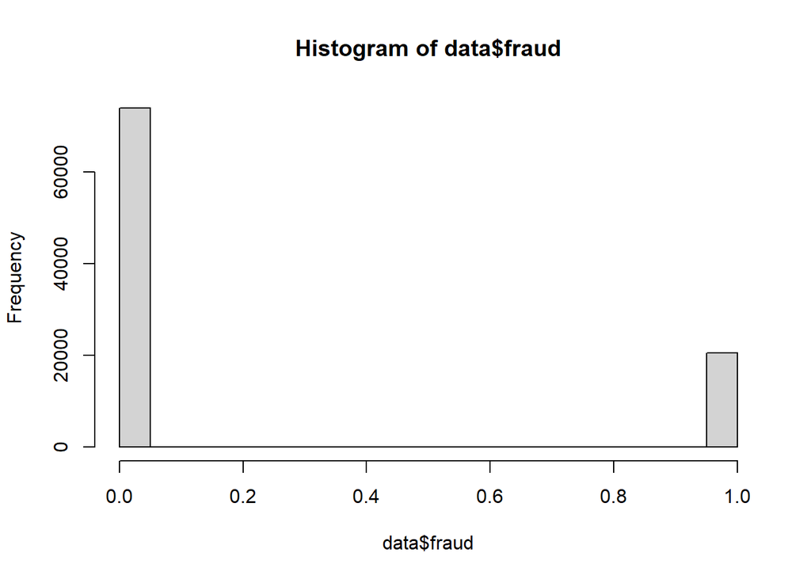

```r
hist(data$fraud)
```

## Valores Atípicos/Outliers

```r
# Assuming data2 is already loaded

# Identify columns that are numeric and not the target
non_target_cols <- setdiff(names(data), "fraud")

# Function to detect outliers in a vector
detect_outliers <- function(x) {
  Q1 <- quantile(x, 0.25, na.rm = TRUE)
  Q3 <- quantile(x, 0.75, na.rm = TRUE)
  IQR <- Q3 - Q1
  lower_bound <- Q1 - 1.5 * IQR
  upper_bound <- Q3 + 1.5 * IQR
  return(x < lower_bound | x > upper_bound)
}

# Apply the function to each column
outliers_list <- lapply(data[non_target_cols], detect_outliers)

# Convert list to data frame and check for rows with any outlier
outliers_df <- as.data.frame(outliers_list)
rows_with_outliers <- apply(outliers_df, 1, any)

# Display rows with outliers
print(data[rows_with_outliers, ])
```

```
## # A tibble: 75,640 × 34
##      tpa policy_ref   member_id   sex   dob policy_start_dt policy_end_dt
##    <dbl>      <dbl>       <dbl> <dbl> <dbl>           <dbl>         <dbl>
##  1     0    9.64e13 86393761621     0 12833           39908         40245
##  2     0    9.64e13 96613477594     1 13223           39908         40245
##  3     0    9.64e13 96613477594     1 13223           39908         40245
##  4     0    9.64e13 96613477594     1 13223           39908         40245
##  5     0    9.64e13 92184431736     1 28572           39908         40245
##  6     0    9.64e13 75362305384     1 30005           39908         40245
##  7     0    9.64e13 77363108540     1 28936           39908         40245
##  8     0    9.64e13 74573053470     0 17926           39908         40245
##  9     0    9.64e13 74573053470     0 17926           39908         40245
## 10     0    9.64e13 74573053470     0 17926           39908         40245
## # ℹ 75,630 more rows
## # ℹ 27 more variables: prod_code <dbl>, policy_type <dbl>, sum_insured <dbl>,
## #   claim_ref <dbl>, claim_dt <dbl>, hos_zipcode <dbl>, admit_dt <dbl>,
## #   discharge_dt <dbl>, payment_dt <dbl>, claim_amt <dbl>, nursing_chg <dbl>,
## #   surgery_chg <dbl>, cons_fee <dbl>, test_chg <dbl>, pharmacy_cost <dbl>,
## #   other_chg <dbl>, pre_hosp_exp <dbl>, post_hosp_exp <dbl>,
## #   other_chg_non_hosp <dbl>, copayment <dbl>, settle_amt <dbl>, …
```

```r
# Count rows with outliers
cat("Number of rows with outliers:", sum(rows_with_outliers), "\n")
```

```
## Number of rows with outliers: 75640
```

```r
# Remove rows with outliers
data2_cleaned <- data[!rows_with_outliers, ]

str(data2_cleaned)
```

```
## tibble [18,845 × 34] (S3: tbl_df/tbl/data.frame)
##  $ tpa                            : num [1:18845] 0 0 0 1 1 1 1 1 1 0 ...
##  $ policy_ref                     : num [1:18845] 9.00e+13 9.45e+13 9.45e+13 9.42e+13 9.20e+13 ...
##  $ member_id                      : num [1:18845] 9.61e+10 9.42e+10 9.42e+10 8.11e+10 7.98e+10 ...
##  $ sex                            : num [1:18845] 0 0 0 0 0 0 0 1 1 0 ...
##  $ dob                            : num [1:18845] 28594 31050 31050 26271 33826 ...
##  $ policy_start_dt                : num [1:18845] 40045 39542 39542 39531 39627 ...
##  $ policy_end_dt                  : num [1:18845] 40409 40112 40112 39895 39991 ...
##  $ prod_code                      : num [1:18845] 0 0 0 0 0 0 0 0 0 0 ...
##  $ policy_type                    : num [1:18845] 3 2 2 3 3 3 3 3 3 3 ...
##  $ sum_insured                    : num [1:18845] 8750 15000 15000 0 0 0 7500 0 0 10000 ...
##  $ claim_ref                      : num [1:18845] 7.68e+19 8.57e+19 7.28e+19 8.98e+19 6.97e+19 ...
##  $ claim_dt                       : num [1:18845] 40174 40178 40177 39678 39680 ...
##  $ hos_zipcode                    : num [1:18845] 9.34e+08 9.35e+08 9.35e+08 7.84e+08 8.81e+08 ...
##  $ admit_dt                       : num [1:18845] 40145 40039 39821 39760 39680 ...
```

[output cut: 22 more lines]

## Normalización del Conjunto de Datos

```r
data2_cleaned1<-as.data.frame(data2_cleaned)
data2<-data2_cleaned

str(data2)
```

```
## tibble [18,845 × 34] (S3: tbl_df/tbl/data.frame)
##  $ tpa                            : num [1:18845] 0 0 0 1 1 1 1 1 1 0 ...
##  $ policy_ref                     : num [1:18845] 9.00e+13 9.45e+13 9.45e+13 9.42e+13 9.20e+13 ...
##  $ member_id                      : num [1:18845] 9.61e+10 9.42e+10 9.42e+10 8.11e+10 7.98e+10 ...
##  $ sex                            : num [1:18845] 0 0 0 0 0 0 0 1 1 0 ...
##  $ dob                            : num [1:18845] 28594 31050 31050 26271 33826 ...
##  $ policy_start_dt                : num [1:18845] 40045 39542 39542 39531 39627 ...
##  $ policy_end_dt                  : num [1:18845] 40409 40112 40112 39895 39991 ...
##  $ prod_code                      : num [1:18845] 0 0 0 0 0 0 0 0 0 0 ...
##  $ policy_type                    : num [1:18845] 3 2 2 3 3 3 3 3 3 3 ...
##  $ sum_insured                    : num [1:18845] 8750 15000 15000 0 0 0 7500 0 0 10000 ...
##  $ claim_ref                      : num [1:18845] 7.68e+19 8.57e+19 7.28e+19 8.98e+19 6.97e+19 ...
##  $ claim_dt                       : num [1:18845] 40174 40178 40177 39678 39680 ...
##  $ hos_zipcode                    : num [1:18845] 9.34e+08 9.35e+08 9.35e+08 7.84e+08 8.81e+08 ...
##  $ admit_dt                       : num [1:18845] 40145 40039 39821 39760 39680 ...
```

[output cut: 22 more lines]

```r
normalize <- function(x) {
  return ((x - min(x)) / (max(x) - min(x)))
}
scaled_data <- as.data.frame(lapply(data2, normalize))
head(scaled_data)
```

```
##          tpa policy_ref member_id sex       dob policy_start_dt policy_end_dt
## 1 0.00000000  0.6527550 0.8727346   0 0.6474600       0.7088025     0.6933265
## 2 0.00000000  0.8129742 0.8021080   0 0.7212425       0.4513818     0.5420275
## 3 0.00000000  0.8129742 0.8021080   0 0.7212425       0.4513818     0.5420275
## 4 0.09090909  0.8031761 0.3291267   0 0.5776730       0.4457523     0.4314824
## 5 0.09090909  0.7245260 0.2808408   0 0.8046384       0.4948823     0.4803872
## 6 0.09090909  0.7031403 0.1956873   0 0.4899811       0.4483112     0.4340295
##   prod_code policy_type sum_insured claim_ref  claim_dt hos_zipcode  admit_dt
## 1       NaN   0.5000000   0.4117647 0.4427662 0.6388110   0.7776091 0.6074866
## 2       NaN   0.3333333   0.7058824 0.7956461 0.6410544   0.7811552 0.5508021
## 3       NaN   0.3333333   0.7058824 0.2819990 0.6404936   0.7811552 0.4342246
## 4       NaN   0.5000000   0.0000000 0.9575895 0.3606282   0.2329022 0.4016043
## 5       NaN   0.5000000   0.0000000 0.1612107 0.3617499   0.5839455 0.3588235
## 6       NaN   0.5000000   0.0000000 0.5204033 0.2865956   0.4673393 0.2545455
##   discharge_dt payment_dt  claim_amt nursing_chg surgery_chg  cons_fee
```

[output cut: 34 more lines]

```r
# Identify columns with NaN values
cols_with_nan <- apply(scaled_data, 2, function(col) any(is.nan(col)))
cols_with_nan
```

```
##                             tpa                      policy_ref
##                           FALSE                           FALSE
##                       member_id                             sex
##                           FALSE                           FALSE
##                             dob                 policy_start_dt
##                           FALSE                           FALSE
##                   policy_end_dt                       prod_code
##                           FALSE                            TRUE
##                     policy_type                     sum_insured
##                           FALSE                           FALSE
##                       claim_ref                        claim_dt
##                           FALSE                           FALSE
##                     hos_zipcode                        admit_dt
##                           FALSE                           FALSE
##                    discharge_dt                      payment_dt
##                           FALSE                           FALSE
##                       claim_amt                     nursing_chg
##                           FALSE                           FALSE
##                     surgery_chg                        cons_fee
##                            TRUE                           FALSE
##                        test_chg                   pharmacy_cost
##                           FALSE                           FALSE
##                       other_chg                    pre_hosp_exp
##                           FALSE                            TRUE
##                   post_hosp_exp              other_chg_non_hosp
##                            TRUE                            TRUE
##                       copayment                      settle_amt
##                            TRUE                           FALSE
##                    payment_type                       hosp_type
##                           FALSE                           FALSE
##                           fraud     recommentdation_sub_genuine
##                           FALSE                            TRUE
##     recommentdation_sub_discuss recommentdation_sub_investigate
##                            TRUE                            TRUE
```

```r
# Remove those columns
scaled_data_cleaned <- scaled_data[, !cols_with_nan]
str(scaled_data_cleaned)
```

```
## 'data.frame':    18845 obs. of  25 variables:
##  $ tpa            : num  0 0 0 0.0909 0.0909 ...
##  $ policy_ref     : num  0.653 0.813 0.813 0.803 0.725 ...
##  $ member_id      : num  0.873 0.802 0.802 0.329 0.281 ...
##  $ sex            : num  0 0 0 0 0 0 0 1 1 0 ...
##  $ dob            : num  0.647 0.721 0.721 0.578 0.805 ...
##  $ policy_start_dt: num  0.709 0.451 0.451 0.446 0.495 ...
##  $ policy_end_dt  : num  0.693 0.542 0.542 0.431 0.48 ...
##  $ policy_type    : num  0.5 0.333 0.333 0.5 0.5 ...
##  $ sum_insured    : num  0.412 0.706 0.706 0 0 ...
##  $ claim_ref      : num  0.443 0.796 0.282 0.958 0.161 ...
##  $ claim_dt       : num  0.639 0.641 0.64 0.361 0.362 ...
##  $ hos_zipcode    : num  0.778 0.781 0.781 0.233 0.584 ...
##  $ admit_dt       : num  0.607 0.551 0.434 0.402 0.359 ...
##  $ discharge_dt   : num  0.596 0.53 0.464 0.393 0.347 ...
##  $ payment_dt     : num  0.474 0.48 0.479 0.193 0.156 ...
##  $ claim_amt      : num  0.228 0.305 0.322 0.125 0.104 ...
##  $ nursing_chg    : num  0 0 0 0.205 0.293 ...
##  $ cons_fee       : num  0 0 0 0.265 0.136 ...
##  $ test_chg       : num  0 0 0 0.777 0.935 ...
##  $ pharmacy_cost  : num  0 0 0 0.2755 0.0741 ...
##  $ other_chg      : num  0.237 0.237 0.237 0.237 0.237 ...
##  $ settle_amt     : num  0.156 0.258 0.137 0.125 0.115 ...
##  $ payment_type   : num  1 0 0 0 0 1 0 0 0 0 ...
##  $ hosp_type      : num  0 1 1 1 1 1 1 1 1 1 ...
##  $ fraud          : num  1 0 0 0 1 1 0 0 0 0 ...
```

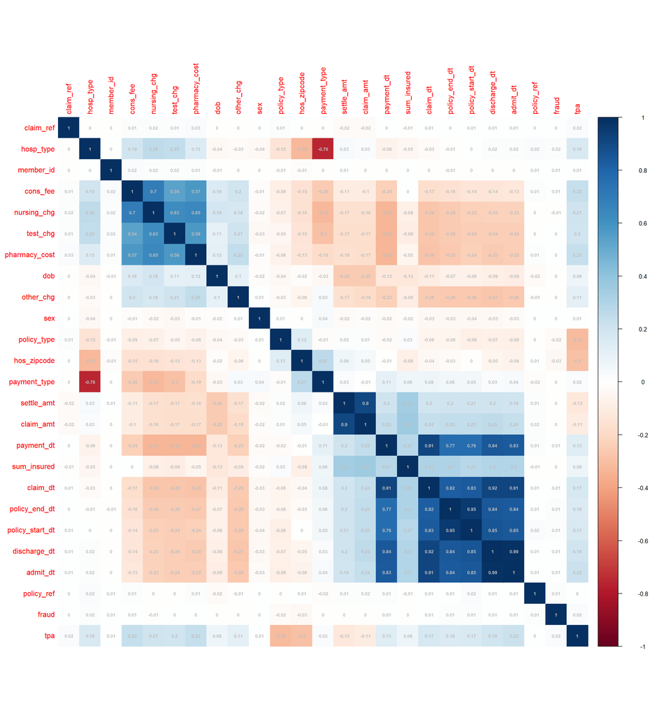

```r
library(corrplot)
corrplot(cor(scaled_data_cleaned),
         method = "color",
         addCoef.col="grey",
         order = "AOE",
         number.cex=0.60)
```

```r
set.seed(123)


# Calculate correlations with the target
correlations <- cor(scaled_data_cleaned)[, "fraud"]

# Remove the correlation of the target with itself
correlations <- correlations[-which(names(correlations) == "fraud")]

# Display the correlations in a single column
result <- data.frame(Feature = names(correlations), Correlation = as.numeric(correlations))
print(result)
```

```
##            Feature   Correlation
## 1              tpa  0.0231559570
## 2       policy_ref  0.0102101587
## 3        member_id  0.0064043056
## 4              sex  0.0026233825
## 5              dob -0.0023993783
## 6  policy_start_dt  0.0105854896
## 7    policy_end_dt  0.0102297508
## 8      policy_type -0.0238030931
## 9      sum_insured -0.0015420737
## 10       claim_ref  0.0046877325
## 11        claim_dt  0.0072329330
## 12     hos_zipcode -0.0318817468
## 13        admit_dt  0.0074141701
## 14    discharge_dt  0.0082738930
## 15      payment_dt  0.0084051555
## 16       claim_amt -0.0035465971
## 17     nursing_chg -0.0093657642
## 18        cons_fee  0.0052556038
## 19        test_chg  0.0003937207
## 20   pharmacy_cost  0.0012866303
## 21       other_chg -0.0044827645
## 22      settle_amt -0.0040081058
## 23    payment_type -0.0048967579
## 24       hosp_type  0.0198699765
```

## División del Conjunto de Datos

```r
scaled_data_cleaned$fraud<-as.factor(scaled_data_cleaned$fraud)
set.seed(123)
trainIndex <- createDataPartition(scaled_data_cleaned$fraud, p = 0.80, list = FALSE)
train_data <- scaled_data_cleaned[trainIndex, ]
test_data <- scaled_data_cleaned[-trainIndex, ]
```

## Regresión Logística

```r
#Regresión Logística

set.seed(423)
model=glm(fraud ~tpa+policy_ref+member_id+sex+policy_start_dt+policy_end_dt+claim_ref+claim_dt+admit_dt+
            discharge_dt+payment_dt+cons_fee+test_chg+pharmacy_cost+hosp_type,
          data=train_data, family=binomial())

summary(model)
```

```
##
## Call:
## glm(formula = fraud ~ tpa + policy_ref + member_id + sex + policy_start_dt +
##     policy_end_dt + claim_ref + claim_dt + admit_dt + discharge_dt +
##     payment_dt + cons_fee + test_chg + pharmacy_cost + hosp_type,
##     family = binomial(), data = train_data)
##
## Coefficients:
##                  Estimate Std. Error z value Pr(>|z|)
## (Intercept)     -1.418549   0.125736 -11.282  < 2e-16 ***
## tpa              0.243104   0.093576   2.598  0.00938 **
## policy_ref       0.100590   0.073388   1.371  0.17049
## member_id        0.020759   0.071763   0.289  0.77238
## sex              0.028896   0.039269   0.736  0.46183
## policy_start_dt  0.077110   0.443539   0.174  0.86198
## policy_end_dt    0.091377   0.471674   0.194  0.84639
## claim_ref        0.002853   0.065521   0.044  0.96527
## claim_dt        -0.100901   0.441711  -0.228  0.81931
## admit_dt        -1.453228   0.853247  -1.703  0.08854 .
## discharge_dt     1.231948   0.927917   1.328  0.18429
## payment_dt       0.268108   0.289282   0.927  0.35403
## cons_fee         0.022923   0.145112   0.158  0.87448
## test_chg        -0.122406   0.130027  -0.941  0.34651
## pharmacy_cost   -0.008105   0.146815  -0.055  0.95598
## hosp_type        0.092438   0.041596   2.222  0.02626 *
## ---
## Signif. codes:  0 '***' 0.001 '**' 0.01 '*' 0.05 '.' 0.1 ' ' 1
##
## (Dispersion parameter for binomial family taken to be 1)
##
##     Null deviance: 16071  on 15076  degrees of freedom
## Residual deviance: 16051  on 15061  degrees of freedom
## AIC: 16083
##
## Number of Fisher Scoring iterations: 4
```

```r
# Hacer predicciones
p_model <- predict(model, test_data, type = "response")
# If p exceeds threshold of 0.5, 1 else 0
reg<- ifelse(p_model > 0.25,1,0)
# Convert the precition into factor
predictions1 <- factor(reg, levels = levels(test_data[["fraud"]]))

# Mostrar matriz de confusión
model_pred <- confusionMatrix(data = predictions1, # predictions
                                  reference = test_data$fraud, # actual
                                  positive = "1",
                                  mode = "everything")
model_pred
```

```
## Confusion Matrix and Statistics
##
##           Reference
## Prediction    0    1
##          0 2726  785
##          1  195   62
##
##                Accuracy : 0.7399
##                  95% CI : (0.7256, 0.7539)
##     No Information Rate : 0.7752
##     P-Value [Acc > NIR] : 1
##
##                   Kappa : 0.0086
##
##  Mcnemar's Test P-Value : <2e-16
##
##             Sensitivity : 0.07320
##             Specificity : 0.93324
##          Pos Pred Value : 0.24125
##          Neg Pred Value : 0.77642
##               Precision : 0.24125
##                  Recall : 0.07320
##                      F1 : 0.11232
##              Prevalence : 0.22479
##          Detection Rate : 0.01645
##    Detection Prevalence : 0.06821
##       Balanced Accuracy : 0.50322
##
##        'Positive' Class : 1
##
```

```r
library(car)
vif(model)
```

```
##             tpa      policy_ref       member_id             sex policy_start_dt
##        1.215698        1.003739        1.000762        1.005356       11.972399
##   policy_end_dt       claim_ref        claim_dt        admit_dt    discharge_dt
##       11.349280        1.001939       11.469112       37.996854       39.146021
##      payment_dt        cons_fee        test_chg   pharmacy_cost       hosp_type
##        6.132991        1.680071        1.758953        1.867612        1.096737
```

A VIF of 1 means the variable is not correlated with other variables. A VIF between 1 and 5 is generally considered acceptable. A VIF above 5 (or 10, depending on the threshold you choose) suggests high multicollinearity which may be problematic.

```r
model2=glm(fraud ~ tpa+policy_ref+member_id+sex+claim_ref+cons_fee+test_chg+pharmacy_cost+hosp_type,
           data=train_data, family=binomial())

summary(model2)
```

```
##
## Call:
## glm(formula = fraud ~ tpa + policy_ref + member_id + sex + claim_ref +
##     cons_fee + test_chg + pharmacy_cost + hosp_type, family = binomial(),
##     data = train_data)
##
## Coefficients:
##                Estimate Std. Error z value Pr(>|z|)
## (Intercept)   -1.375286   0.069042 -19.920   <2e-16 ***
## tpa            0.224822   0.088543   2.539   0.0111 *
## policy_ref     0.102136   0.073279   1.394   0.1634
## member_id      0.022013   0.071744   0.307   0.7590
## sex            0.027354   0.039209   0.698   0.4854
## claim_ref      0.003629   0.065501   0.055   0.9558
## cons_fee       0.005870   0.144628   0.041   0.9676
## test_chg      -0.136313   0.127796  -1.067   0.2861
## pharmacy_cost -0.024070   0.143332  -0.168   0.8666
## hosp_type      0.089911   0.041382   2.173   0.0298 *
## ---
## Signif. codes:  0 '***' 0.001 '**' 0.01 '*' 0.05 '.' 0.1 ' ' 1
##
## (Dispersion parameter for binomial family taken to be 1)
##
##     Null deviance: 16071  on 15076  degrees of freedom
## Residual deviance: 16056  on 15067  degrees of freedom
## AIC: 16076
##
## Number of Fisher Scoring iterations: 4
```

```r
# hacer predicciones
p_model <- predict(model2, test_data, type = "response")
# If p exceeds threshold of 0.5, 1 else 0
reg<- ifelse(p_model > 0.25,1,0)
# Convertir la predicción a factor
predictions1 <- factor(reg, levels = levels(test_data[["fraud"]]))

# Mostrar metricas de confusión
model_pred1 <- confusionMatrix(data = predictions1, # predictions
                                  reference = test_data$fraud, # actual
                                  positive = "1",
                                  mode = "everything")
model_pred1
```

```
## Confusion Matrix and Statistics
##
##           Reference
## Prediction    0    1
##          0 2782  801
##          1  139   46
##
##                Accuracy : 0.7505
##                  95% CI : (0.7364, 0.7643)
##     No Information Rate : 0.7752
##     P-Value [Acc > NIR] : 0.9998
##
##                   Kappa : 0.0093
##
##  Mcnemar's Test P-Value : <2e-16
##
##             Sensitivity : 0.05431
##             Specificity : 0.95241
##          Pos Pred Value : 0.24865
##          Neg Pred Value : 0.77644
##               Precision : 0.24865
##                  Recall : 0.05431
##                      F1 : 0.08915
##              Prevalence : 0.22479
##          Detection Rate : 0.01221
##    Detection Prevalence : 0.04910
##       Balanced Accuracy : 0.50336
##
##        'Positive' Class : 1
##
```

## Gradient Boosting

```r
model_gbm <- gbm(fraud ~ tpa+policy_ref+member_id+sex+claim_ref+cons_fee+test_chg+pharmacy_cost+hosp_type, data=train_data)
```

```
## Distribution not specified, assuming bernoulli ...
```

```r
print(model_gbm)
```

```
## gbm(formula = fraud ~ tpa + policy_ref + member_id + sex + claim_ref +
##     cons_fee + test_chg + pharmacy_cost + hosp_type, data = train_data)
## A gradient boosted model with bernoulli loss function.
## 100 iterations were performed.
## There were 9 predictors of which 0 had non-zero influence.
```

```r
# Hacer las predicciones
p_model <- predict(model_gbm, test_data, type = "response")
```

```
## Using 100 trees...
```

```r
# If p exceeds threshold of 0.5, 1 else 0
reg<- ifelse(p_model > 0.25,1,0)
# Convert the precition into factor
predictions1 <- factor(reg, levels = levels(test_data[["fraud"]]))

# Mostrar metricas de confusión
model_pred <- confusionMatrix(data = predictions1, # predictions
                                  reference = test_data$fraud, # actual
                                  positive = "1",
                                  mode = "everything")
model_pred
```

```
## Confusion Matrix and Statistics
##
##           Reference
## Prediction 0 1
##          0 0 0
##          1 0 0
##
##                Accuracy : NaN
##                  95% CI : (NA, NA)
##     No Information Rate : NA
##     P-Value [Acc > NIR] : NA
##
##                   Kappa : NaN
##
##  Mcnemar's Test P-Value : NA
##
##             Sensitivity :  NA
##             Specificity :  NA
##          Pos Pred Value :  NA
##          Neg Pred Value :  NA
##               Precision :  NA
##                  Recall :  NA
##                      F1 :  NA
##              Prevalence : NaN
##          Detection Rate : NaN
##    Detection Prevalence : NaN
##       Balanced Accuracy :  NA
##
##        'Positive' Class : 1
##
```

GBM results are not good for this dataset so we used random forest its also belongs to same family.

### Random FOrest

```r
library(randomForest)
set.seed(423)
# Aplicar el modelo
RF=randomForest(fraud ~tpa+policy_ref+member_id+sex+claim_ref+cons_fee+test_chg+pharmacy_cost+hosp_type,
           data=train_data)
print(RF)
```

```
##
## Call:
##  randomForest(formula = fraud ~ tpa + policy_ref + member_id +      sex + claim_ref + cons_fee + test_chg + pharmacy_cost + hosp_type,      data = train_data)
##                Type of random forest: classification
##                      Number of trees: 500
## No. of variables tried at each split: 3
##
##         OOB estimate of  error rate: 22.79%
## Confusion matrix:
##       0  1 class.error
## 0 11606 81 0.006930778
## 1  3355 35 0.989675516
```

```r
# Hacer las predicciones
p_model4 <- predict(RF, test_data, type = "class")
predictions4 <- factor(p_model4, levels = levels(test_data[["fraud"]]))

# Mostrar metricas de confusión
RFF <- confusionMatrix(data = predictions4, # predictions
                                  reference = test_data$fraud, # actual
                                  positive = "1",
                                  mode = "everything")
RFF
```

```
## Confusion Matrix and Statistics
##
##           Reference
## Prediction    0    1
##          0 2907  842
##          1   14    5
##
##                Accuracy : 0.7728
##                  95% CI : (0.7591, 0.7861)
##     No Information Rate : 0.7752
##     P-Value [Acc > NIR] : 0.6457
##
##                   Kappa : 0.0017
##
##  Mcnemar's Test P-Value : <2e-16
##
##             Sensitivity : 0.005903
##             Specificity : 0.995207
##          Pos Pred Value : 0.263158
##          Neg Pred Value : 0.775407
##               Precision : 0.263158
##                  Recall : 0.005903
##                      F1 : 0.011547
##              Prevalence : 0.224788
##          Detection Rate : 0.001327
##    Detection Prevalence : 0.005042
##       Balanced Accuracy : 0.500555
##
##        'Positive' Class : 1
##
```

## Accuracy of glm and random forest

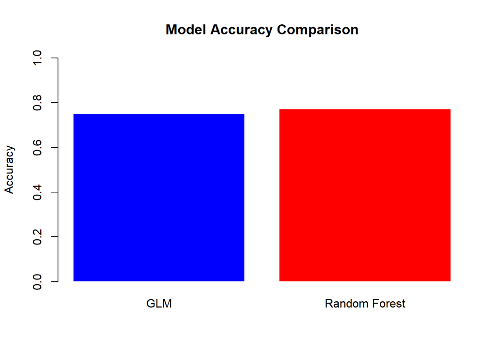

```r
glm_accuracy <- model_pred1$overall['Accuracy']
rf_accuracy <- RFF$overall['Accuracy']

# Extract Accuracy
glm_accuracy <- model_pred1$overall['Accuracy']
rf_accuracy <- RFF$overall['Accuracy']

# Plotting
accuracy_values <- c(glm_accuracy, rf_accuracy)
names(accuracy_values) <- c("GLM", "Random Forest")

barplot(accuracy_values,
        main="Model Accuracy Comparison",
        ylim=c(0, 1),
        col=c("blue", "red"),
        border="white",
        ylab="Accuracy")
```

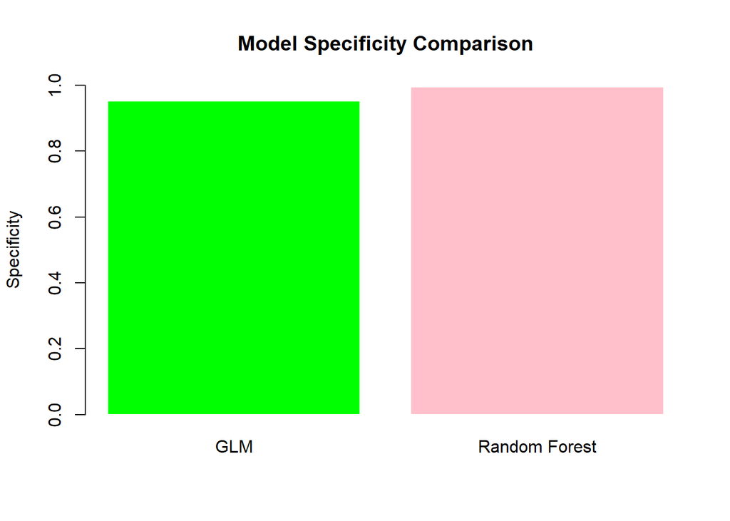

```r
glm_specificity <- model_pred1$byClass['Specificity']
rf_specificity <- RFF$byClass['Specificity']

# Extract Specificity
glm_specificity <- model_pred1$byClass['Specificity']
rf_specificity <- RFF$byClass['Specificity']

# Plotting
specificity_values <- c(glm_specificity, rf_specificity)
names(specificity_values) <- c("GLM", "Random Forest")

barplot(specificity_values,
        main="Model Specificity Comparison",
        ylim=c(0, 1),
        col=c("green", "pink"),
        border="white",
        ylab="Specificity")
```

## Directed Acyclic Graph (DAG) Analysis

### Define a DAG

```r
#install.packages(c("ggraph", "igraph"))
library(ggraph)
library(igraph)
```

Una representación textual de nuestras suposiciones para el DAG:

El tpa puede influir en claim_ref ya que podrían estar involucrados en el procesamiento de reclamos. El sexo podría tener una influencia indirecta en cons_fee, test_chg, pharmacy_cost según el tipo de tratamientos. policy_start_dt y policy_end_dt podrían influir en claim_dt ya que los reclamos deben estar dentro de la duración de la póliza. claim_dt, admit_dt, discharge_dt pueden influir en payment_dt ya que el pago se realiza típicamente después del alta. cons_fee, test_chg, pharmacy_cost juntos dan una idea del costo total del tratamiento. Desviaciones en estos podrían indicar fraude. hosp_type (Tipo de Hospital) podría influir en cons_fee, test_chg, pharmacy_cost según la tarificación del hospital.